# Creativity Studio Report

Alyssa Carr

2023-02-03

[figure not shown]

# About this report

This report presents findings from a study of visitors to the *Creativity Studio*. Two iterations of the *Creativity Studio* were evaluated, one connected to the *Weaving Splendor: Treasures of Asian Textiles* special exhibition, and one connected to the *American Art Deco: Designing for the People 1918 - 1939* special exhibition. While each exhibition focused on different art objects and different eras both iteractions of the *Creativity Studio* provided a space for visitors to get hands on after being inspired by the exhibitions they had just viewed.

In the *Weaving Splendor* exhibition visitors were able to view rarely seen Chinese, Indian, Japanese, Persian, and Turkish clothing and textiles from *The Nelson-Atkins Museum of Art’s* collection. The adjoining *Creativity Studio* encouraged visitors to design their own garment, weave on a six-foot-tall loom, embroider around a large table, or watch process videos that offered glimpses into the creative practices of artists from around the world.

In the *American Art Deco* exhibition visitors were viewed works of art, design, and architecture of the Art Deco era. The *Creativity Studio* at the end of the exhibition offered a participatory space in order to foster creativity, social connections, and informal learning. Visitors were encouraged to “mix and match” building blocks to design their own Art Deco city, design their own building topper, view projections of 1920’s and 1930’s Kansas City, read books, and relax.

# Methodology

# Participant Demographics

## Race/Ethnicity

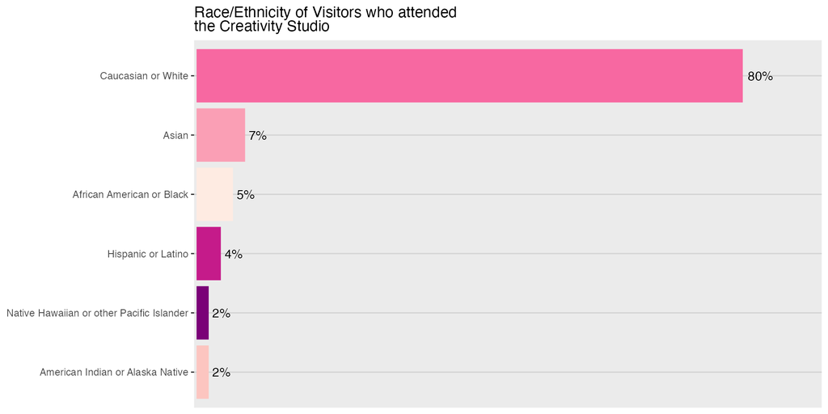

[output not shown]

[output cut: 365 more lines]

[output not shown]

## Age

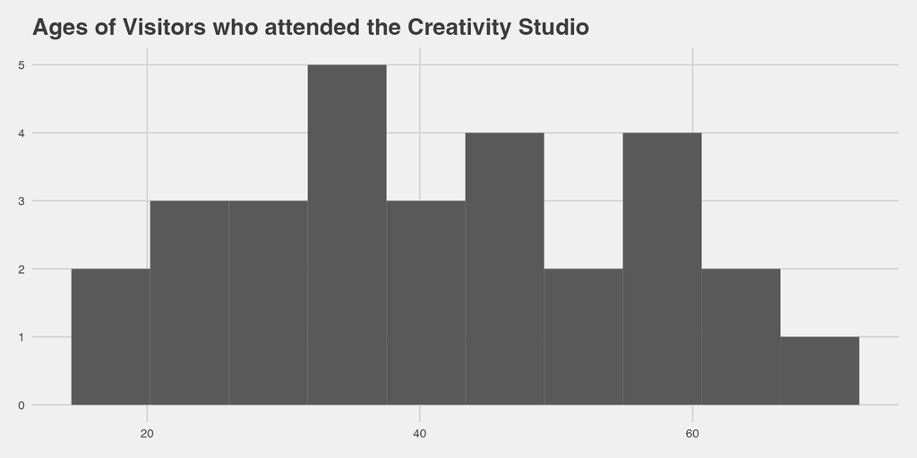

## What brought you to the museum today?

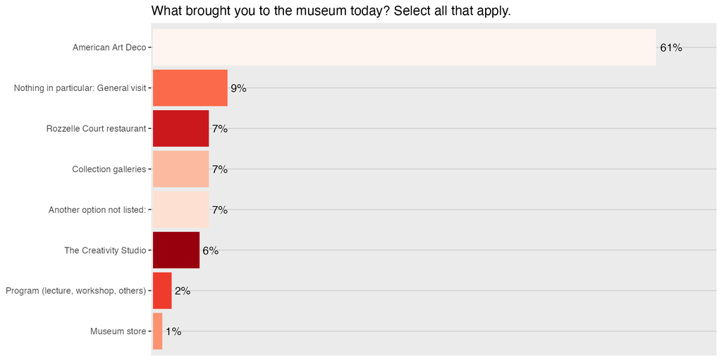

## Participant Demographics at a Glance

- 15% of visitors came to the museum with the intention of visiting the *Creativity Studio*
- 70% of visitors who attended the *American Art Deco* exhibition also visited the *Creativity Studio*

```
## # A tibble: 2 × 4
##   did_you_plan_to_attend_the_creativity_studio_when_you_de…¹     n   pct perce…²
##   <chr>                                                      <int> <dbl> <chr>
## 1 No                                                            55 0.846 85%
## 2 Yes                                                           10 0.154 15%
## # … with abbreviated variable names
## #   ¹did_you_plan_to_attend_the_creativity_studio_when_you_decided_to_come_to_the_museum_today,
## #   ²percent_display
```

```
## # A tibble: 2 × 4
##   did_visitor_agree_to_take_the_survey_selected_choice     n    pct percent_di…¹
##   <chr>                                                <int>  <dbl> <chr>
## 1 No (provide reason given)                               10 0.0935 9%
## 2 Yes                                                     97 0.907  91%
## # … with abbreviated variable name ¹percent_display
```

```
## # A tibble: 7 × 2
##   did_visitor_agree_to_take_the_survey_no_provide_reason_given_text     n
##   <chr>                                                             <int>
## 1 Chiefs!                                                               1
## 2 Felt that they did not do enough to evaluate                          1
## 3 In a hurry                                                            1
## 4 No reason given                                                       1
## 5 No time                                                               3
## 6 None provided                                                         1
## 7 Not today                                                             1
```

```
## # A tibble: 3 × 4
##   did_you_attend_the_creativity_studio_today                    n    pct perce…¹
##   <chr>                                                     <int>  <dbl> <chr>
## 1 No                                                            2 0.0204 2%
## 2 No, I just walked through it on my way out of the Art De…    27 0.276  28%
## 3 Yes                                                          69 0.704  70%
## # … with abbreviated variable name ¹percent_display
```

```
## # A tibble: 5 × 2
##   way_heard                            n
##   <chr>                            <int>
## 1 During my last visit                 1
## 2 Nelson-Atkins website                1
## 3 Signs at the museum                  4
## 4 While in the Art Deco exhibition     4
## 5 Word of Mouth (Friends, Family)      3
```

## Activities

[figure not shown]

```
## # A tibble: 4 × 2
##   what_did_you_and_your_group_do_in_the_creativity_studio_select_all_tha…¹     n
##   <chr>                                                                    <int>
## 1 Checked out the boxes on display                                             1
## 2 Just watched kids                                                            1
## 3 Looked at boxes                                                              1
## 4 Toppled my building                                                          1
## # … with abbreviated variable name
## #   ¹what_did_you_and_your_group_do_in_the_creativity_studio_select_all_that_apply_another_option_not_listed_text
```

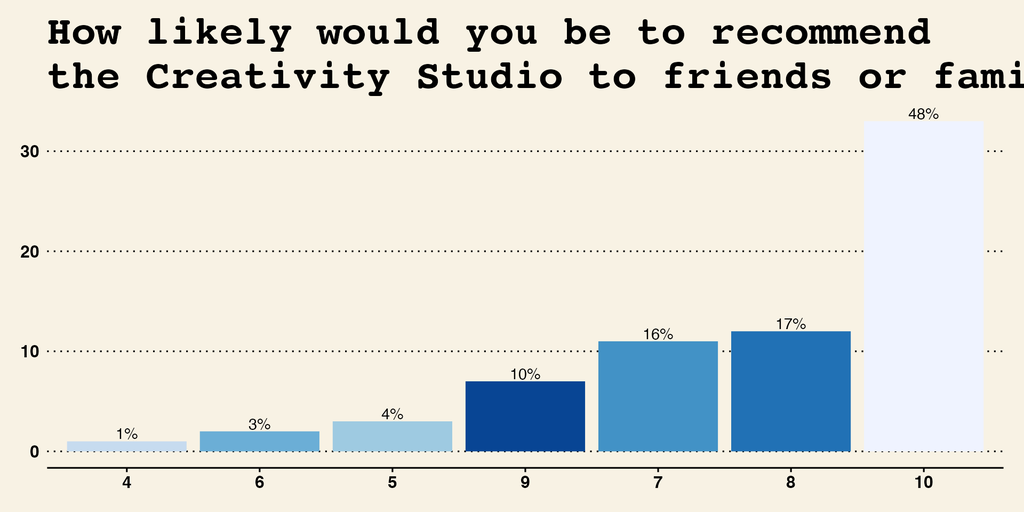

```
## # A tibble: 42 × 2
##    please_say_a_few_words_explaining_why_you_gave_it_that_rating_in_the_…¹     n
##    <chr>                                                                   <int>
##  1 Creative                                                                    1
##  2 Excellent interaction                                                       1
##  3 Fun, creative and has a variety of activities to do.                        1
##  4 Fun!                                                                        1
##  5 Gives young people a chance to interact with art                            1
##  6 Great break for young children                                              1
##  7 Great for kids!                                                             1
##  8 I enjoyed it, but not sure how many people I know would be interested       1
##  9 I love having activities and resources that help engage different peop…     1
## 10 I thought it was a fun end to the exhibit and a nice break for younger…     1
## # … with 32 more rows, and abbreviated variable name
## #   ¹please_say_a_few_words_explaining_why_you_gave_it_that_rating_in_the_space_below
```

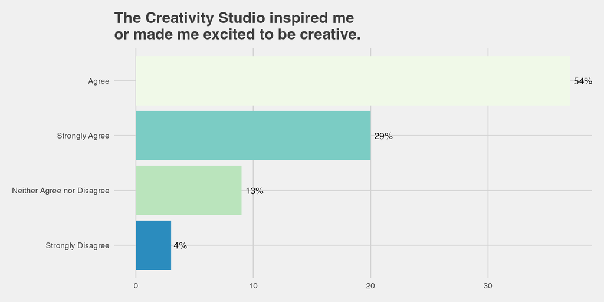

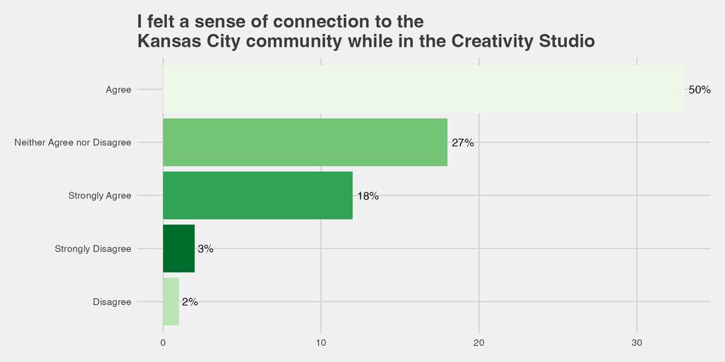

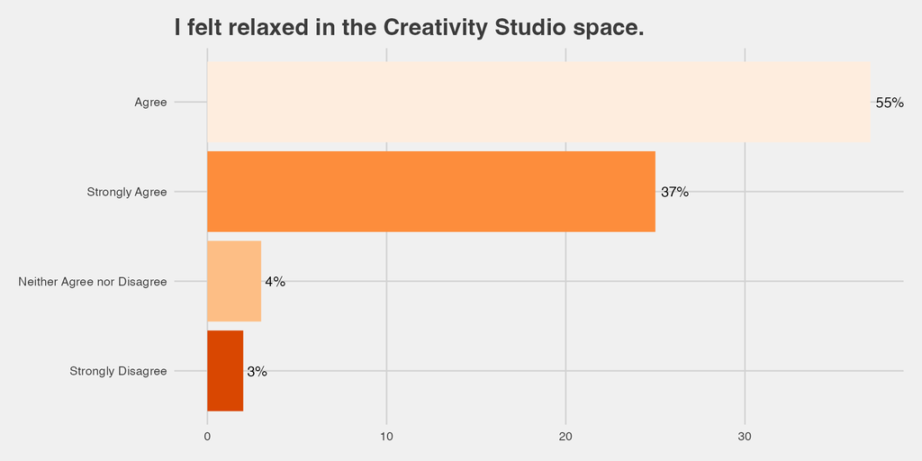

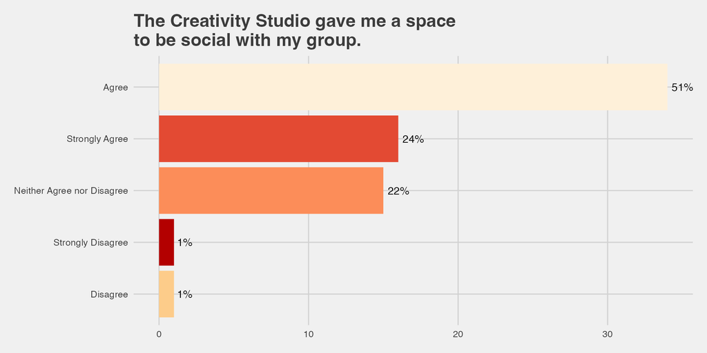

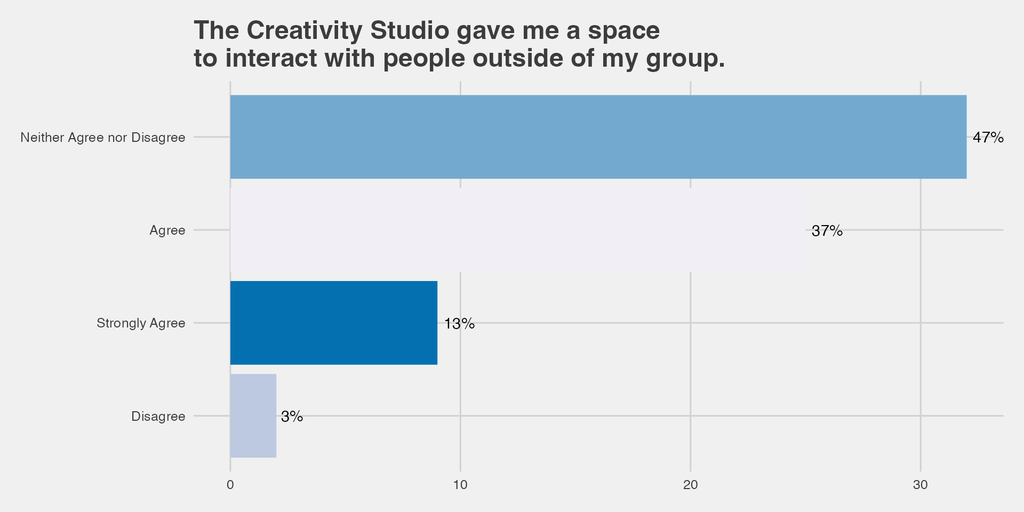

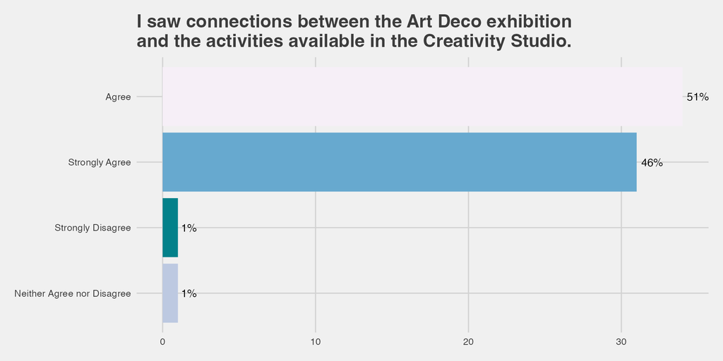

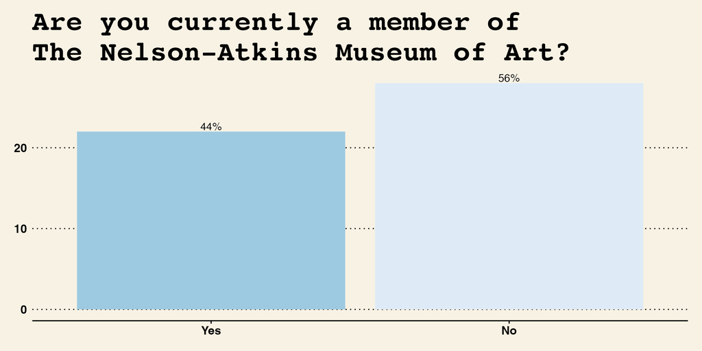

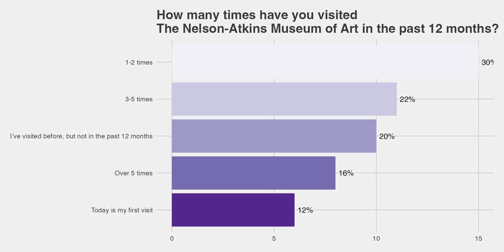

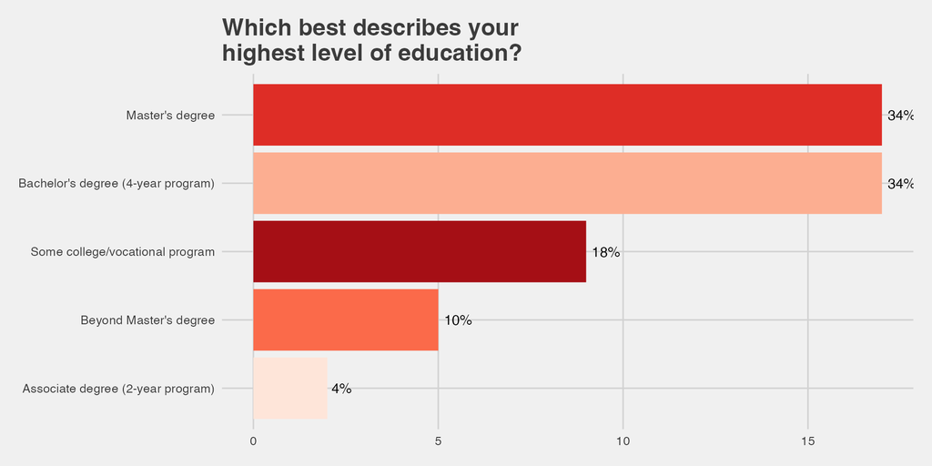

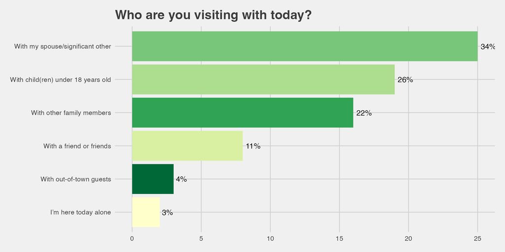

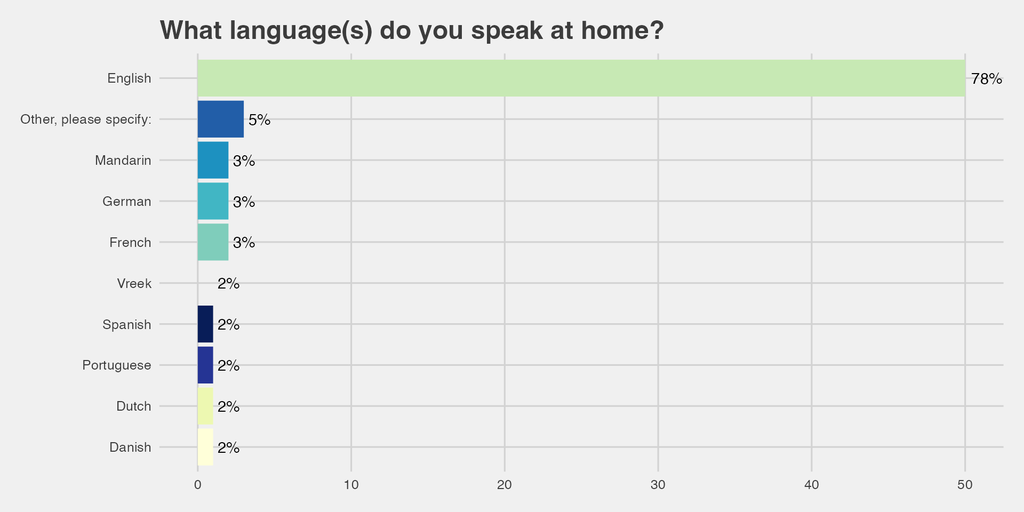

```
## # A tibble: 35 × 2
##    what_is_your_zip_code     n
##    <chr>                 <int>
##  1 10035                     1
##  2 63109                     1
##  3 64015                     1
##  4 64055                     1
##  5 64068                     1
##  6 64086                     1
##  7 64106                     1
##  8 64108                     1
##  9 64109                     2
## 10 64110                     4
## # … with 25 more rows
```

```
## # A tibble: 15 × 2
##    please_let_us_know_if_you_have_any_additional_thoughts_or_comments          n
##    <chr>                                                                   <int>
##  1 Do more similar activities like this.                                       1
##  2 Good ending to exhibit esp w children                                       1
##  3 Great exhibit. Good fashion. Informative yet aware wall text. Could ha…     1
##  4 Great idea                                                                  1
##  5 I enjoyed the experience                                                    1
##  6 I liked it                                                                  1
##  7 I love this exhibit!                                                        1
##  8 love the custom designed building blocks - want to buy some for kids a…     1
##  9 Love the diversity                                                          1
## 10 My son would love to have these building blocks                             1
## 11 Nice place to visit                                                         1
## 12 Thank you,                                                                  1
## 13 Thank you.                                                                  1
## 14 Very nice                                                                   1
## 15 Would like more tie in to existing Kansa City buildings downtown, both…     1
```

```
## # A tibble: 2 × 9
##   what_did_you_and_your_group…¹  `10`   `4`   `5`   `6`   `7`   `8`   `9` `<NA>`
##   <chr>                         <int> <int> <int> <int> <int> <int> <int>  <int>
## 1 I or someone in my group rea…     8    NA     1    NA     3     1    NA      1
## 2 <NA>                             25     1     2     2     8    11     7     40
## # … with abbreviated variable name
## #   ¹what_did_you_and_your_group_do_in_the_creativity_studio_select_all_that_apply_selected_choice_i_or_someone_in_my_group_read_books_available_including_adults_and_children_in_your_group_reading_on_their_own
```

```
## # A tibble: 2 × 9
##   what_did_you_and_your_group…¹  `10`   `4`   `5`   `6`   `7`   `8`   `9` `<NA>`
##   <chr>                         <int> <int> <int> <int> <int> <int> <int>  <int>
## 1 Another option not listed:        2    NA    NA    NA     1    NA     1     NA
## 2 <NA>                             31     1     3     2    10    12     6     41
## # … with abbreviated variable name
## #   ¹what_did_you_and_your_group_do_in_the_creativity_studio_select_all_that_apply_selected_choice_another_option_not_listed
```

```
## # A tibble: 2 × 9
##   what_did_you_and_your_group…¹  `10`   `4`   `5`   `6`   `7`   `8`   `9` `<NA>`
##   <chr>                         <int> <int> <int> <int> <int> <int> <int>  <int>
## 1 "Answered questions or asked…     2    NA    NA    NA     2    NA     1     NA
## 2  <NA>                            31     1     3     2     9    12     6     41
## # … with abbreviated variable name
## #   ¹what_did_you_and_your_group_do_in_the_creativity_studio_select_all_that_apply_selected_choice_answered_questions_or_asked_others_in_my_group_to_answer_questions_written_on_the_walls
```

```
## # A tibble: 2 × 9
##   what_did_you_and_your_group…¹  `10`   `4`   `5`   `6`   `7`   `8`   `9` `<NA>`
##   <chr>                         <int> <int> <int> <int> <int> <int> <int>  <int>
## 1 "Designed a building with bl…    18     1    NA    NA     9     7     3     NA
## 2  <NA>                            15    NA     3     2     2     5     4     41
## # … with abbreviated variable name
## #   ¹what_did_you_and_your_group_do_in_the_creativity_studio_select_all_that_apply_selected_choice_designed_a_building_with_blocks
```

```
## # A tibble: 2 × 9
##   what_did_you_and_your_group…¹  `10`   `4`   `5`   `6`   `7`   `8`   `9` `<NA>`
##   <chr>                         <int> <int> <int> <int> <int> <int> <int>  <int>
## 1 "Designed my own building to…    19     1    NA    NA     4     1     2     NA
## 2  <NA>                            14    NA     3     2     7    11     5     41
## # … with abbreviated variable name
## #   ¹what_did_you_and_your_group_do_in_the_creativity_studio_select_all_that_apply_selected_choice_designed_my_own_building_topper
```

```
## # A tibble: 2 × 9
##   what_did_you_and_your_group…¹  `10`   `4`   `5`   `6`   `7`   `8`   `9` `<NA>`
##   <chr>                         <int> <int> <int> <int> <int> <int> <int>  <int>
## 1 I or someone in my group had…     9     1    NA     1     3     1    NA     NA
## 2 <NA>                             24    NA     3     1     8    11     7     41
## # … with abbreviated variable name
## #   ¹what_did_you_and_your_group_do_in_the_creativity_studio_select_all_that_apply_selected_choice_i_or_someone_in_my_group_had_a_conversation_with_someone_outside_of_our_group_including_other_visitors_or_staff
```

```
## # A tibble: 2 × 9
##   what_did_you_and_your_group…¹  `10`   `4`   `5`   `6`   `7`   `8`   `9` `<NA>`
##   <chr>                         <int> <int> <int> <int> <int> <int> <int>  <int>
## 1 I or someone in my group rea…     8    NA     1    NA     3     1    NA      1
## 2 <NA>                             25     1     2     2     8    11     7     40
## # … with abbreviated variable name
## #   ¹what_did_you_and_your_group_do_in_the_creativity_studio_select_all_that_apply_selected_choice_i_or_someone_in_my_group_read_books_available_including_adults_and_children_in_your_group_reading_on_their_own
```

```
## # A tibble: 2 × 9
##   what_did_you_and_your_group…¹  `10`   `4`   `5`   `6`   `7`   `8`   `9` `<NA>`
##   <chr>                         <int> <int> <int> <int> <int> <int> <int>  <int>
## 1 I or someone in my group rea…     3    NA    NA    NA    NA    NA    NA     NA
## 2 <NA>                             30     1     3     2    11    12     7     41
## # … with abbreviated variable name
## #   ¹what_did_you_and_your_group_do_in_the_creativity_studio_select_all_that_apply_selected_choice_i_or_someone_in_my_group_read_books_with_or_to_children
```

```
## # A tibble: 2 × 9
##   what_did_you_and_your_group…¹  `10`   `4`   `5`   `6`   `7`   `8`   `9` `<NA>`
##   <chr>                         <int> <int> <int> <int> <int> <int> <int>  <int>
## 1 I or someone in my group had…     9     1    NA     1     3     1    NA     NA
## 2 <NA>                             24    NA     3     1     8    11     7     41
## # … with abbreviated variable name
## #   ¹what_did_you_and_your_group_do_in_the_creativity_studio_select_all_that_apply_selected_choice_i_or_someone_in_my_group_had_a_conversation_with_someone_outside_of_our_group_including_other_visitors_or_staff
```

```
## # A tibble: 2 × 9
##   what_did_you_and_your_group…¹  `10`   `4`   `5`   `6`   `7`   `8`   `9` `<NA>`
##   <chr>                         <int> <int> <int> <int> <int> <int> <int>  <int>
## 1 I or someone in my group sha…     8    NA    NA    NA    NA     1     2     NA
## 2 <NA>                             25     1     3     2    11    11     5     41
## # … with abbreviated variable name
## #   ¹what_did_you_and_your_group_do_in_the_creativity_studio_select_all_that_apply_selected_choice_i_or_someone_in_my_group_shared_something_to_social_media_or_are_planning_to
```

```
## # A tibble: 2 × 9
##   what_did_you_and_your_group…¹  `10`   `4`   `5`   `6`   `7`   `8`   `9` `<NA>`
##   <chr>                         <int> <int> <int> <int> <int> <int> <int>  <int>
## 1 "Looked at pictures of the K…    25     1     1     2     8     7     4     NA
## 2  <NA>                             8    NA     2    NA     3     5     3     41
## # … with abbreviated variable name
## #   ¹what_did_you_and_your_group_do_in_the_creativity_studio_select_all_that_apply_selected_choice_looked_at_pictures_of_the_kansas_city_skyline_projected_on_the_wall
```

```
## # A tibble: 2 × 9
##   what_did_you_and_your_group…¹  `10`   `4`   `5`   `6`   `7`   `8`   `9` `<NA>`
##   <chr>                         <int> <int> <int> <int> <int> <int> <int>  <int>
## 1 "Answered questions or asked…     2    NA    NA    NA     2    NA     1     NA
## 2  <NA>                            31     1     3     2     9    12     6     41
## # … with abbreviated variable name
## #   ¹what_did_you_and_your_group_do_in_the_creativity_studio_select_all_that_apply_selected_choice_answered_questions_or_asked_others_in_my_group_to_answer_questions_written_on_the_walls
```

```
## # A tibble: 2 × 9
##   what_did_you_and_your_group…¹  `10`   `4`   `5`   `6`   `7`   `8`   `9` `<NA>`
##   <chr>                         <int> <int> <int> <int> <int> <int> <int>  <int>
## 1 "Took a break in seating are…    19     1     2    NA     6     4     3     NA
## 2  <NA>                            14    NA     1     2     5     8     4     41
## # … with abbreviated variable name
## #   ¹what_did_you_and_your_group_do_in_the_creativity_studio_select_all_that_apply_selected_choice_took_a_break_in_seating_area
```

```
## # A tibble: 5 × 9
##   please_rate_your_agreement_…¹  `10`   `4`   `5`   `6`   `7`   `8`   `9` `<NA>`
##   <chr>                         <int> <int> <int> <int> <int> <int> <int>  <int>
## 1 Agree                            16     1    NA     1     9     7     3     NA
## 2 Neither Agree nor Disagree        2    NA     3     1     1     1    NA      1
## 3 Strongly Agree                   12    NA    NA    NA     1     4     3     NA
## 4 Strongly Disagree                 3    NA    NA    NA    NA    NA    NA     NA
## 5 <NA>                             NA    NA    NA    NA    NA    NA     1     40
## # … with abbreviated variable name
## #   ¹please_rate_your_agreement_with_the_following_statements_the_creativity_studio_inspired_me_or_made_me_excited_to_be_creative
```

```
## # A tibble: 5 × 9
##   please_rate_your_agreement_…¹  `10`   `4`   `5`   `6`   `7`   `8`   `9` `<NA>`
##   <chr>                         <int> <int> <int> <int> <int> <int> <int>  <int>
## 1 Agree                            13    NA    NA     2     3     3     4     NA
## 2 Disagree                         NA    NA    NA    NA     1     1    NA     NA
## 3 Neither Agree nor Disagree       13     1     3    NA     7     6     2     NA
## 4 Strongly Agree                    7    NA    NA    NA    NA     2    NA     NA
## 5 <NA>                             NA    NA    NA    NA    NA    NA     1     41
## # … with abbreviated variable name
## #   ¹please_rate_your_agreement_with_the_following_statements_the_creativity_studio_gave_me_a_space_to_interact_with_people_outside_of_my_group
```

```
## # A tibble: 6 × 9
##   please_rate_your_agreement_…¹  `10`   `4`   `5`   `6`   `7`   `8`   `9` `<NA>`
##   <chr>                         <int> <int> <int> <int> <int> <int> <int>  <int>
## 1 Agree                            16    NA     2     1     5     4     6     NA
## 2 Disagree                         NA    NA    NA    NA    NA     1    NA     NA
## 3 Neither Agree nor Disagree        7     1     1     1     1     4    NA     NA
## 4 Strongly Agree                    9    NA    NA    NA     5     2    NA     NA
## 5 Strongly Disagree                 1    NA    NA    NA    NA    NA    NA     NA
## 6 <NA>                             NA    NA    NA    NA    NA     1     1     41
## # … with abbreviated variable name
## #   ¹please_rate_your_agreement_with_the_following_statements_the_creativity_studio_gave_me_a_space_to_be_social_with_my_group
```

```
## # A tibble: 5 × 9
##   please_rate_your_agreement_…¹  `10`   `4`   `5`   `6`   `7`   `8`   `9` `<NA>`
##   <chr>                         <int> <int> <int> <int> <int> <int> <int>  <int>
## 1 Agree                            12     1     1     1     9     7     3     NA
## 2 Neither Agree nor Disagree       NA    NA     1    NA    NA    NA    NA     NA
## 3 Strongly Agree                   19    NA     1     1     2     5     3     NA
## 4 Strongly Disagree                 1    NA    NA    NA    NA    NA    NA     NA
## 5 <NA>                              1    NA    NA    NA    NA    NA     1     41
## # … with abbreviated variable name
## #   ¹please_rate_your_agreement_with_the_following_statements_i_saw_connections_between_the_art_deco_exhibition_and_the_activities_available_in_the_creativity_studio
```

```
## # A tibble: 5 × 9
##   please_rate_your_agreement_…¹  `10`   `4`   `5`   `6`   `7`   `8`   `9` `<NA>`
##   <chr>                         <int> <int> <int> <int> <int> <int> <int>  <int>
## 1 Agree                            13     1     2     1     8     9     3     NA
## 2 Neither Agree nor Disagree        1    NA     1     1    NA    NA    NA     NA
## 3 Strongly Agree                   17    NA    NA    NA     2     3     3     NA
## 4 Strongly Disagree                 2    NA    NA    NA    NA    NA    NA     NA
## 5 <NA>                             NA    NA    NA    NA     1    NA     1     41
## # … with abbreviated variable name
## #   ¹please_rate_your_agreement_with_the_following_statements_i_felt_relaxed_in_the_creativity_studio_space
```

```
## # A tibble: 6 × 9
##   please_rate_your_agreement_…¹  `10`   `4`   `5`   `6`   `7`   `8`   `9` `<NA>`
##   <chr>                         <int> <int> <int> <int> <int> <int> <int>  <int>
## 1 Agree                            16     1     2     1     5     3     5     NA
## 2 Disagree                          1    NA    NA    NA    NA    NA    NA     NA
## 3 Neither Agree nor Disagree        7    NA     1     1     5     4    NA     NA
## 4 Strongly Agree                    7    NA    NA    NA    NA     4     1     NA
## 5 Strongly Disagree                 2    NA    NA    NA    NA    NA    NA     NA
## 6 <NA>                             NA    NA    NA    NA     1     1     1     41
## # … with abbreviated variable name
## #   ¹please_rate_your_agreement_with_the_following_statements_i_felt_a_sense_of_connection_to_the_kansas_city_community_while_in_the_creativity_studio
```